# SIM - Project

Ignacio Lloret and Iñigo Pikabea

2023-10-09

## Data Reading

```r
df <- read.csv("C:/MDS/SIM/Project/data/train.csv")
# df <- read.csv("C:/Users/inigo/Documents/UPC/SIM/SIM-project/data/train.csv")
```

## Keep columns

```r
##################
numeric_columns <- c("LotFrontage", "LotArea", "YearBuilt", "YearRemodAdd", "MasVnrArea", "BsmtFinSF1", "BsmtFinSF2", "BsmtUnfSF", "TotalBsmtSF", "X1stFlrSF", "X2ndFlrSF", "LowQualFinSF", "GrLivArea", "BsmtFullBath", "BsmtHalfBath", "FullBath", "HalfBath", "BedroomAbvGr", "KitchenAbvGr", "TotRmsAbvGrd", "Fireplaces", "GarageYrBlt", "GarageCars", "GarageArea", "WoodDeckSF", "OpenPorchSF", "EnclosedPorch", "X3SsnPorch", "ScreenPorch", "PoolArea", "MiscVal", "MoSold", "YrSold", "OverallCond","OverallQual","SalePrice")

cat_keep <- c("FireplaceQu","KitchenQual","BsmtFinType1","BsmtExposure","BsmtQual","Foundation","Neighborhood","LotShape","MSSubClass","Exterior1st","Exterior2nd", "SaleCondition")

df1 <- df %>% select(all_of(numeric_columns), all_of(cat_keep))
```

# Exploratory Data Analysis

## Missing data

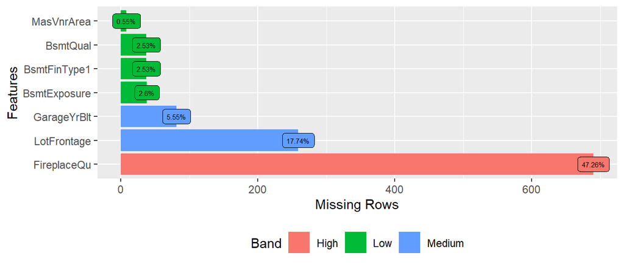

```r
plot_missing(df1, missing_only = TRUE, group = list("Low" = 0.05, "Medium"=0.25, "High"=0.5, "Very High" =1), geom_label_args = list("size" = 2))
```

## Categorical values

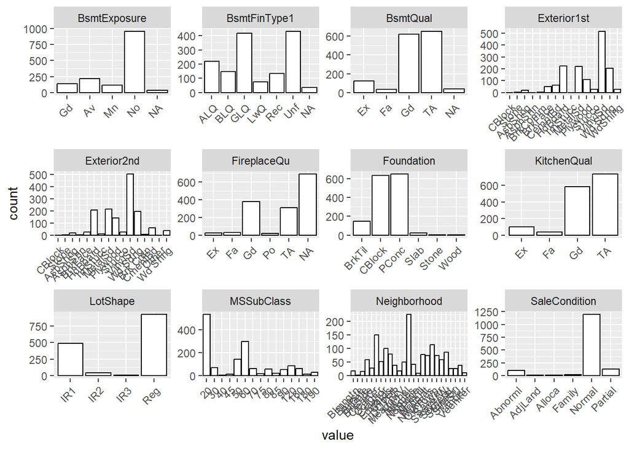

```r
df1[cat_keep] <- lapply(df1[cat_keep], as.factor) ## Create Factors
df1[numeric_columns] <- lapply(df1[numeric_columns], as.numeric)


p1 <- df1 %>%
  select(all_of(cat_keep)) %>%
  pivot_longer(cols=everything()) %>%
  ggplot(data=.) +
  geom_bar(aes(x=value), col="black", fill="white") +
  theme(axis.text.x = element_text(angle = 45, hjust = 1)) +
  facet_wrap(~name, scales="free", ncol=4)
p1
```

## Numerical Data

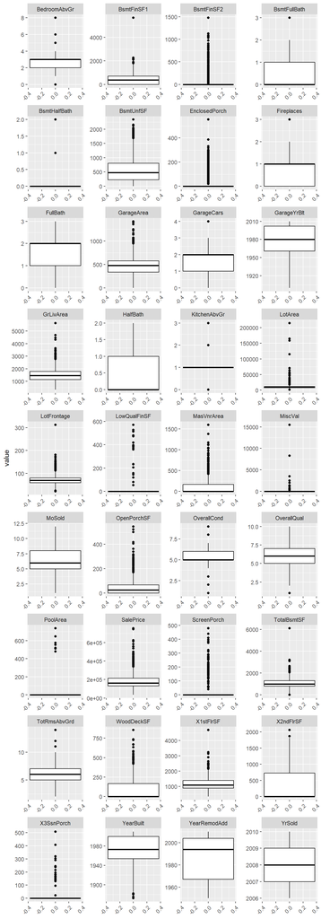

```r
p2 <- df1 %>%
  select(all_of(numeric_columns)) %>%
  pivot_longer(cols=everything()) %>%
  ggplot(data=.) +
  geom_boxplot(aes(y=value), col="black", fill="white") +
  theme(axis.text.x = element_text(angle = 45, hjust = 1)) +
  facet_wrap(~name, scales="free", ncol=4)
p2
```

## Normality Test

Based on the analysis performed, we concluded that the distribution of the SalePrice variable in the dataset does not follow a normal distribution.

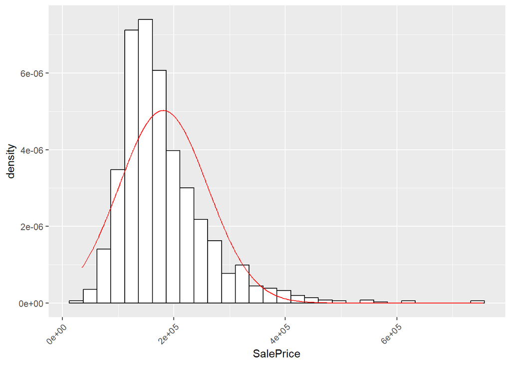

```r
library(stats)
# Calculate mean and standard deviation
mean <- mean(df1$SalePrice)
sd <- sd(df1$SalePrice)

# Create a variable of sequence from minimum to maximum with 0.01 increments
x <- seq(min(df1$SalePrice), max(df1$SalePrice), length = 100)

# Add a 'Density' column to the data
data <- df1 %>%
  mutate(Density = dnorm(SalePrice, mean = mean, sd = sd))

# Generating the histogram
ggplot(data, aes(x = SalePrice)) +
  geom_histogram(aes(y = ..density..), bins = 30, colour = 'black', fill = 'white') +
  geom_line(aes(y = Density), colour = 'red') +
  theme(axis.text.x = element_text(angle = 45, hjust = 1))
```

```r
shapiro.test(df1$SalePrice) ## It is not normal
```

```
##
##  Shapiro-Wilk normality test
##
## data:  df1$SalePrice
## W = 0.86967, p-value < 2.2e-16
```

## Test serial correlation

There is no autocorrelation in the data as we see in the plot and in the Durbin Watson test. As the p-value is greater than .05.

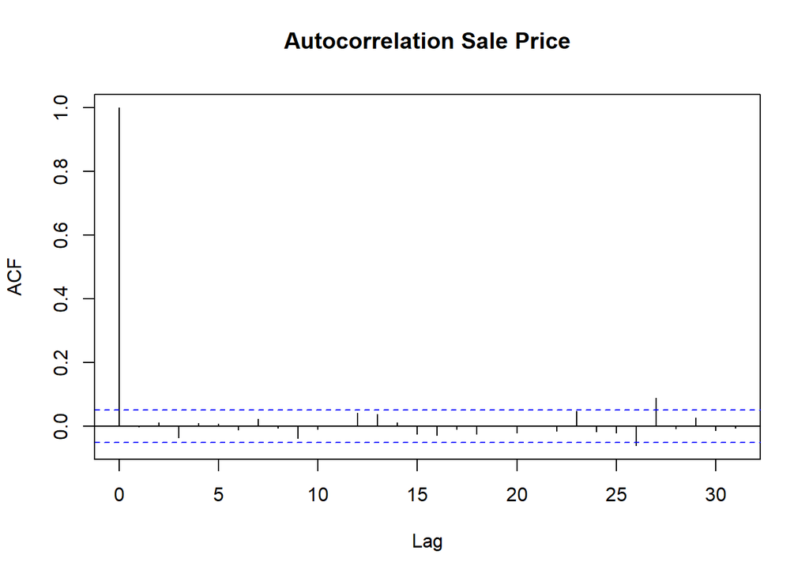

```r
acf(df1$SalePrice, main="Autocorrelation Sale Price")
```

```r
dwtest(SalePrice ~1, data=df1)
```

```
##
##  Durbin-Watson test
##
## data:  SalePrice ~ 1
## DW = 2.0026, p-value = 0.5199
## alternative hypothesis: true autocorrelation is greater than 0
```

## Univariate Outliers transformation

```r
## Looking at the data exploration part we can distinguish multiple columns which have outliers, we will plot a geom_histogram to see them better

num_outliers <- c("BsmtFinSF1", "BsmtFinSF2", "BsmtHalfBath", "BsmtUnfSF", "EnclosedPorch", "GarageArea", "GrLivArea","LotArea", "LotFrontage", "LowQualFinSF", "MasVnrArea","MiscVal","OpenPorchSF","PoolArea","ScreenPorch","TotalBsmtSF", "WoodDeckSF","X1stFlrSF","X3SsnPorch")

# Create a list to store the plots
plots <- list()

columna <- "MasVnrArea"
# Loop through each numeric column
for(i in 1:length(num_outliers)) {
  columna <- num_outliers[i]

  # Calculate the thresholds
  q1 <- quantile(df1[columna],0.25, na.rm = TRUE)
  q3 <- quantile(df1[columna],0.75, na.rm = TRUE)
  iqr <- q3 - q1
  mild_l <- q1 - iqr*1.5
  mild_h <- q3 + iqr*1.5
  high_l <- q1 - iqr*3
  high_h <- q3 + iqr*3

  # Create the plot
  p <- ggplot(df1, aes(x=!!sym(columna))) +
    geom_histogram(color="black", fill="white", bins=30) +
    geom_vline(aes(xintercept=mild_l), color="blue", linetype="dashed") +
    geom_vline(aes(xintercept=mild_h), color="blue", linetype="dashed") +
    geom_vline(aes(xintercept=high_l), color="red", linetype="dashed") +
    geom_vline(aes(xintercept=high_h), color="red", linetype="dashed") +
    labs(x = columna, y="Frequency", title = paste("Histogram of", columna))
  # Add the plot to the list
  print(p)
}


## Multivariate
```

[output not shown]

## NA imputation

After imputing the data logically, creating the levels NoFirePlace and NoBasement, we perform advanced imputation for imputing numerical values, creating sinthetic values.

```r
## Impute missing data by creating extra modality

df1$FireplaceQu <- ifelse(df1$FireplaceQu %>% is.na, "NoFirePlace", df1$FireplaceQu)
df1$BsmtExposure <- ifelse(df1$BsmtExposure %>% is.na, "NoBasement", df1$BsmtExposure)
df1$BsmtFinType1 <- ifelse(df1$BsmtFinType1 %>% is.na, "NoBasement", df1$BsmtFinType1)
df1$BsmtQual <- ifelse(df1$BsmtQual %>% is.na, "NoBasement", df1$BsmtQual)

df1$garage <- ifelse(df1$GarageYrBlt %>% is.na, "NO", "YES")
## Impute with synthetic values
df2 <- mice(df1, method = "cart")
```

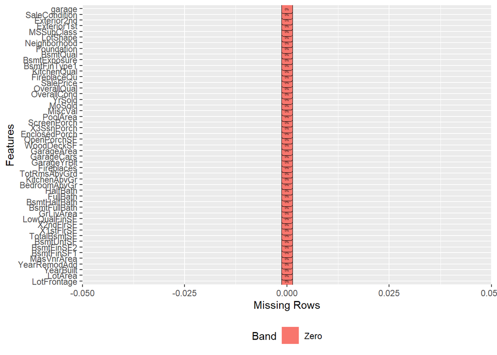

```r
df3 <- complete(df2)

plot_missing(df3, missing_only = FALSE, group = list("Zero"=0,"Low" = 0.05, "Medium"=0.25, "High"=0.5, "Very High" =1), geom_label_args = list("size" = 1))
```

## Correlation Matrix

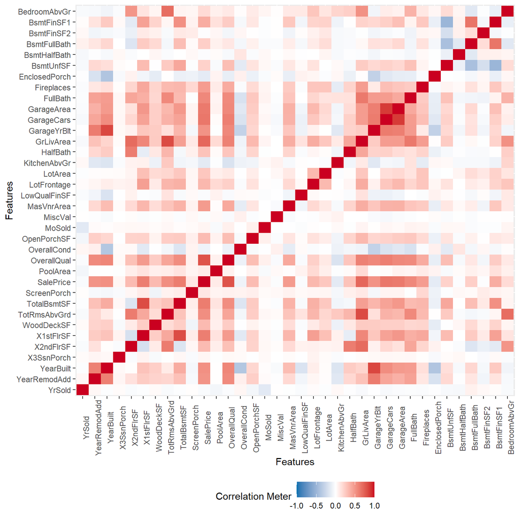

```r
df_num <- df3[order(numeric_columns, decreasing = TRUE)]

plot_correlation(df_num)
```

## Numerical transformation

In order to minimize the effect of 0 values in the dataset we will create a dummy variable for No Basement. It will be very useful for modelling as we will use it to create interactions with the numerical features.

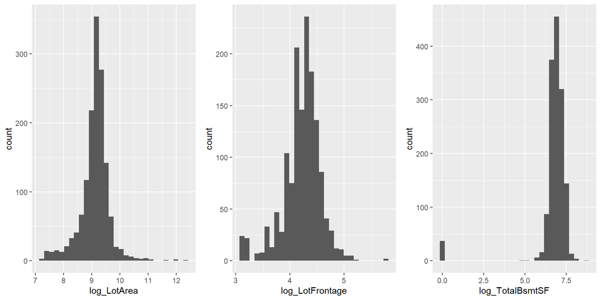

```r
df3$log_LotArea <- log(df3$LotArea + 1)
df3$log_LotFrontage <- log(df3$LotFrontage + 1)
df3$log_TotalBsmtSF <- log(df3$TotalBsmtSF + 1)

df3$YearRemodAdd <- df3$YearRemodAdd - df3$YearBuilt

g1 <- ggplot(df3) + geom_histogram(aes(x=log_LotArea))
g2 <- ggplot(df3) + geom_histogram(aes(x=log_LotFrontage))
g3 <- ggplot(df3) + geom_histogram(aes(x=log_TotalBsmtSF))

grid.arrange(g1,g2,g3, ncol=3)
```

```r
df3$bsmt <- ifelse(df3$log_TotalBsmtSF == 0, "NO","YES")
```

## Categorization transformation

We opted to transform some features into categories because many data points in some variables are zeros, which might be less informative for analysis. Variables like BsmtFinSF2, EnclosedPorch, LowQualFinSF, and others are transformed. If the original value is greater than zero, it’s categorized as “Yes”; otherwise, it’s labeled “Zero” or “No”. This transformation improves interpretability and is beneficial for statistical analyses, particularly when dealing with variables heavily skewed towards zero.

```r
df3$cat_BsmntFinSF2 <- ifelse(df3$BsmtFinSF2 > 0, "Yes","Zero")
df3$cat_EnclosedPorch <- ifelse(df3$EnclosedPorch > 0, "Yes","Zero")
df3$cat_LowQualFinSF <- ifelse(df3$LowQualFinSF > 0, "Yes","Zero")
df3$cat_MiscVal <- ifelse(df3$MiscVal > 0, "Yes","Zero")
df3$cat_PoolArea <- ifelse(df3$PoolArea > 0, "Yes","No")
df3$cat_ScreenPorch <- ifelse(df3$ScreenPorch > 0, "Yes","No")
df3$cat_X3SsnPorch <- ifelse(df3$X3SsnPorch > 0, "Yes","No")
df3$remod <- ifelse(df3$YearRemodAdd == 0, "No", "Yes")

df3$SaleCondition <- relevel(x=df3$SaleCondition, ref="Normal")
```

## Interaction between numerical and categorical

The first graph shows the variation in sale prices of properties across different Neighborhoods.. The neighorhood can significantly influence its sale price.This graph helps to understand if certain neighorhoods have higher or lower average prices.

The second graph shows the variation in sale prices of properties across different municipal zoning classifications (MSZoning), which may include residential, commercial, agricultural, etc. The zoning of a property can significantly influence its sale price due to factors such as proximity to amenities, population density, and municipal regulations. This graph helps to understand if certain zones have higher or lower average prices.

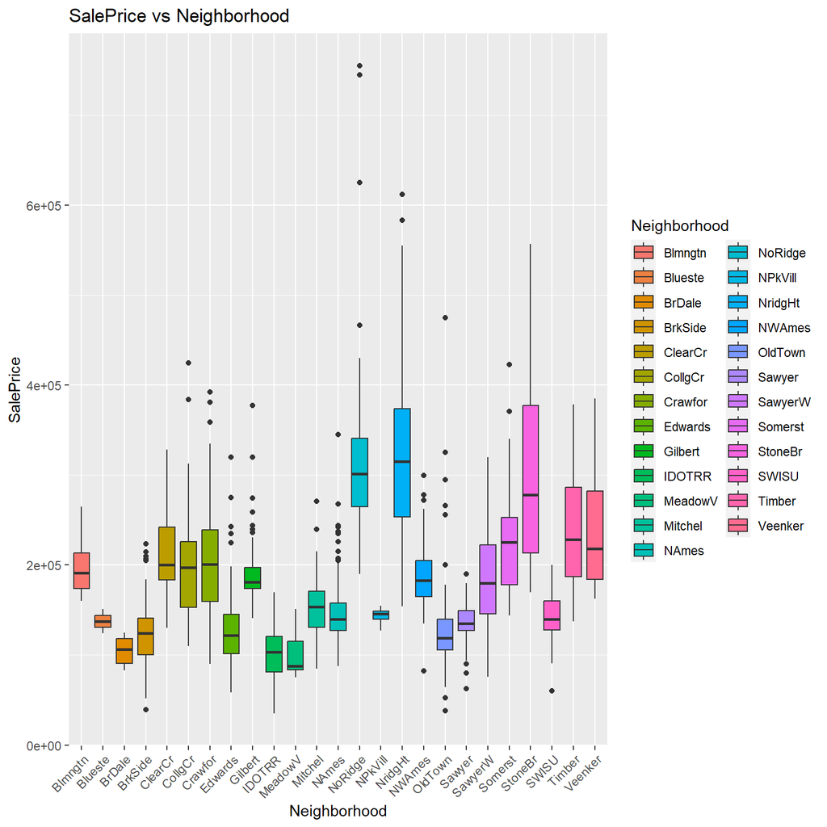

```r
g1 <- ggplot(data=df3) +
  geom_boxplot(aes(y=SalePrice, x = Neighborhood, fill=Neighborhood))  +
    labs(title="SalePrice vs Neighborhood") +
    theme(axis.text.x = element_text(angle = 45, hjust = 1))

g2 <- ggplot(df, aes(x=MSZoning, y=SalePrice, fill=MSZoning)) +
    geom_boxplot() +
    labs(title="SalePrice vs MSZoning") +
    theme(axis.text.x = element_text(angle = 45, hjust = 1))

g3 <- ggplot(df, aes(x=SaleCondition, y=SalePrice, fill=SaleCondition)) +
    geom_boxplot() +
    labs(title="SalePrice vs SaleCondition") +
    theme(axis.text.x = element_text(angle = 45, hjust = 1))

g4 <- ggplot(df, aes(x=KitchenQual, y=SalePrice, fill=KitchenQual)) +
    geom_boxplot() +
    labs(title="SalePrice vs KitchenQual") +
    theme(axis.text.x = element_text(angle = 45, hjust = 1))
g1
```

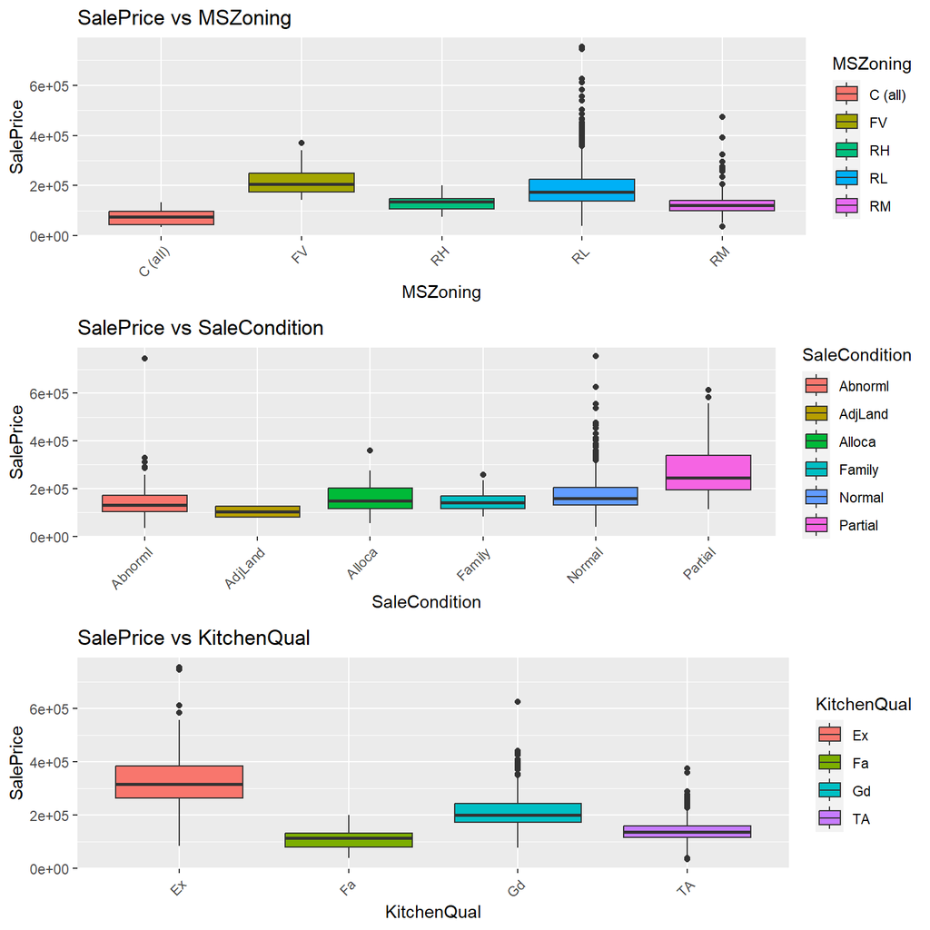

```r
grid.arrange(g2,g3,g4)
```

## Multivariate outliers

In our analysis with the Moutlier function, we faced issues due to the poor distribution of some numeric variables, which caused computational errors. To resolve this, we excluded variables with fewer than 50 unique values. This step was necessary to ensure the effectiveness of the outlier detection process, as variables with limited unique values can hinder the accurate identification of outliers. Additionally, we identified and removed multivariate outliers (moutliers) from our training dataset. These outliers are observations that significantly deviate from the norm across several dimensions. Removing these moutliers is crucial for enhancing model accuracy, as they can skew results and lead to misleading interpretations.

```r
set.seed(1)
numeric_columns <- c("log_LotFrontage", "log_LotArea", "MasVnrArea", "BsmtFinSF1", "BsmtUnfSF", "log_TotalBsmtSF", "X1stFlrSF", "X2ndFlrSF", "GrLivArea", "BsmtFullBath", "BsmtHalfBath", "FullBath", "HalfBath", "BedroomAbvGr", "KitchenAbvGr", "TotRmsAbvGrd", "Fireplaces", "GarageYrBlt", "GarageCars", "GarageArea", "WoodDeckSF", "OpenPorchSF", "MoSold", "YrSold", "OverallCond","OverallQual","SalePrice")


df_clean = df3[complete.cases(df3[, numeric_columns]), numeric_columns]

sum(is.na(df_clean))
```

```
## [1] 0
```

```r
data_numeric <- df_clean[, sapply(df_clean, is.numeric)]

threshold <- 50

filtered_numeric_vars <- sapply(data_numeric, function(x) length(unique(x)) > threshold)
final_numeric_data <- data_numeric[, filtered_numeric_vars]

res.out = Moutlier(final_numeric_data[, !(names(final_numeric_data) %in% c("LotFrontage", "log_LotArea", "TotalBsmtSF", "YearBuilt", "YearRemodAdd", "MasVnrArea", "BsmtFinSF2", "X2ndFlrSF", "WoodDeckSF", "EnclosedPorch", "ScreenPorch"))], quantile = 0.9995, col="green")
```

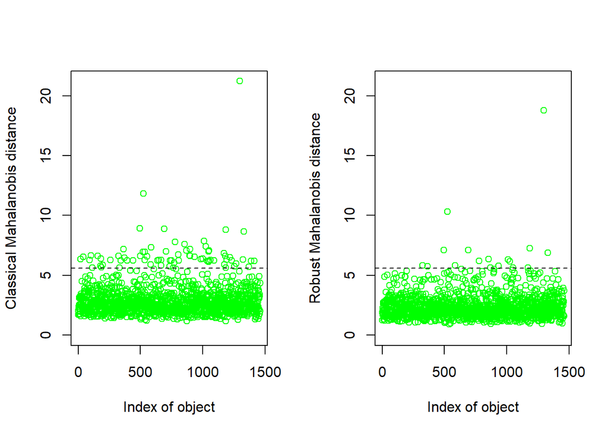

```r
outlier_index <- which((res.out$md > res.out$cutoff)&(res.out$rd > res.out$cutoff))
length(outlier_index)
```

```
## [1] 17
```

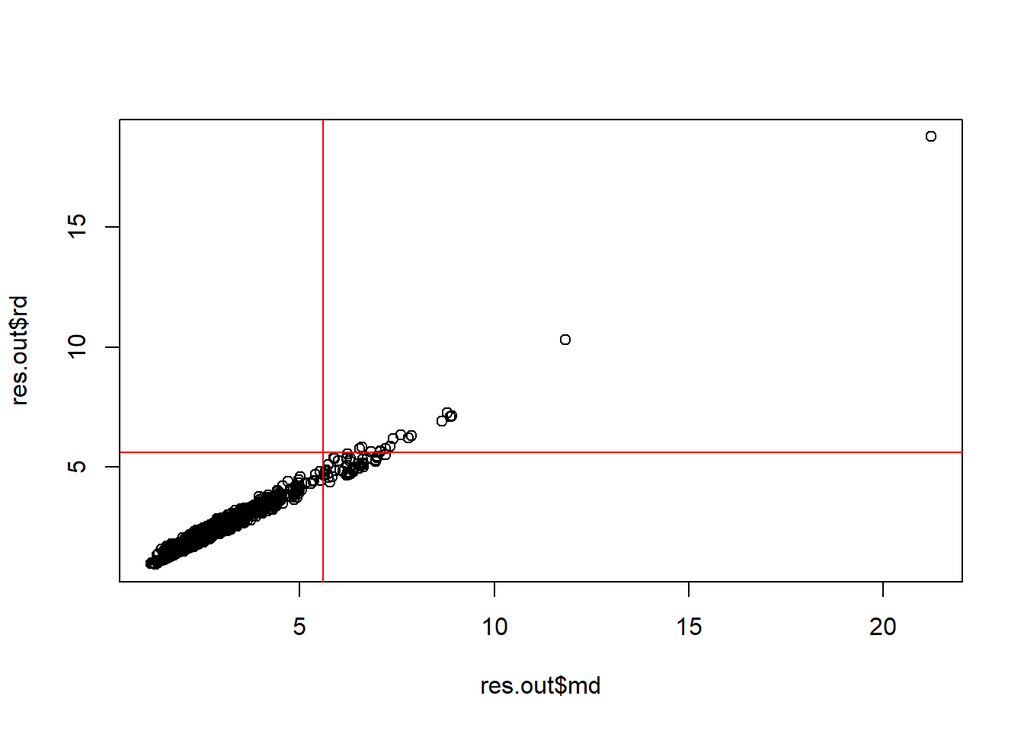

```r
par(mfrow=c(1,1))
plot( res.out$md, res.out$rd )
abline(h=res.out$cutoff, col="red")
abline(v=res.out$cutoff, col="red")
```

```r
df3 <- df3[-outlier_index, ]
```

## Model

```r
## First we will add all the variables that are do not have correlation between each other. We have iterated to keep those that are not multicolinear with each other by adding and removing. But keeping always the ones that we preprocessed.

df_model <- df3 %>% select(
  c(
    "log_LotFrontage",
    "log_LotArea",
    "YearBuilt",
    "YearRemodAdd",
    "FullBath",
    "garage",
    "GarageArea",
    "bsmt",
    "log_TotalBsmtSF",
    "cat_PoolArea",
    "YrSold",
    "MoSold",
    "remod",
    "GarageCars",
    "GarageYrBlt",
    "BedroomAbvGr",
    "KitchenAbvGr",
    "TotRmsAbvGrd",
    "Neighborhood",
    "GrLivArea",
    "MSSubClass",
    "X1stFlrSF",
    "X2ndFlrSF",
    "OverallCond",
    "OverallQual",
    "FireplaceQu",
    "cat_MiscVal",
    "OpenPorchSF",
    "cat_EnclosedPorch",
    "cat_LowQualFinSF",
    "cat_X3SsnPorch",
    "ScreenPorch",
    "Foundation",
    "Exterior1st",
    "Exterior2nd",
    "SaleCondition",
    "SalePrice"
    )
)


attach(df_model)
mod1_raw <- lm(SalePrice ~ log_LotFrontage + log_LotArea + X1stFlrSF + X2ndFlrSF + YearBuilt + YearRemodAdd + FullBath + GarageArea + GarageCars + GarageYrBlt:garage + BedroomAbvGr + KitchenAbvGr + TotRmsAbvGrd + Neighborhood + MSSubClass + log_TotalBsmtSF + cat_PoolArea + YrSold:MoSold + OverallCond + OverallQual + FireplaceQu + cat_MiscVal + OpenPorchSF + ScreenPorch + Foundation +SaleCondition, data=df_model)
summary(mod1_raw)
```

```
##
## Call:
## lm(formula = SalePrice ~ log_LotFrontage + log_LotArea + X1stFlrSF +
##     X2ndFlrSF + YearBuilt + YearRemodAdd + FullBath + GarageArea +
##     GarageCars + GarageYrBlt:garage + BedroomAbvGr + KitchenAbvGr +
##     TotRmsAbvGrd + Neighborhood + MSSubClass + log_TotalBsmtSF +
##     cat_PoolArea + YrSold:MoSold + OverallCond + OverallQual +
##     FireplaceQu + cat_MiscVal + OpenPorchSF + ScreenPorch + Foundation +
##     SaleCondition, data = df_model)
##
## Residuals:
##     Min      1Q  Median      3Q     Max
## -155972  -13347     307   12252  200522
##
## Coefficients:
##                          Estimate Std. Error t value Pr(>|t|)
## (Intercept)            -1.158e+06  1.767e+05  -6.556 7.79e-11 ***
## log_LotFrontage        -6.173e+03  3.416e+03  -1.807 0.070992 .
## log_LotArea             1.952e+04  2.519e+03   7.751 1.76e-14 ***
## X1stFlrSF               7.676e+01  4.403e+00  17.434  < 2e-16 ***
## X2ndFlrSF               5.452e+01  5.008e+00  10.887  < 2e-16 ***
## YearBuilt               5.270e+02  8.921e+01   5.908 4.37e-09 ***
## YearRemodAdd            2.699e+01  5.446e+01   0.496 0.620295
## FullBath               -2.235e+03  2.103e+03  -1.063 0.288179
## GarageArea              8.551e+00  8.289e+00   1.032 0.302438
## GarageCars              8.498e+03  2.399e+03   3.541 0.000411 ***
## BedroomAbvGr           -1.107e+04  1.405e+03  -7.884 6.44e-15 ***
## KitchenAbvGr           -2.267e+04  5.722e+03  -3.961 7.84e-05 ***
## TotRmsAbvGrd            3.514e+03  9.969e+02   3.525 0.000437 ***
## NeighborhoodBlueste     2.237e+04  2.038e+04   1.098 0.272457
## NeighborhoodBrDale      1.943e+04  1.116e+04   1.741 0.081862 .
## NeighborhoodBrkSide     8.669e+03  9.038e+03   0.959 0.337636
## NeighborhoodClearCr     3.439e+03  9.464e+03   0.363 0.716338
## NeighborhoodCollgCr    -4.124e+03  7.772e+03  -0.531 0.595773
## NeighborhoodCrawfor     2.251e+04  8.785e+03   2.562 0.010508 *
## NeighborhoodEdwards    -5.185e+03  8.388e+03  -0.618 0.536584
## NeighborhoodGilbert    -1.028e+04  8.188e+03  -1.256 0.209439
## NeighborhoodIDOTRR     -1.743e+03  9.486e+03  -0.184 0.854208
## NeighborhoodMeadowV     1.747e+04  1.118e+04   1.562 0.118477
## NeighborhoodMitchel    -8.422e+03  8.552e+03  -0.985 0.324915
```

[output cut: 43 more lines]

```
## FoundationWood         -1.958e+04  1.585e+04  -1.235 0.217042
## SaleConditionAbnorml   -9.488e+03  2.832e+03  -3.351 0.000828 ***
## SaleConditionAdjLand    9.849e+03  1.397e+04   0.705 0.481001
## SaleConditionAlloca    -6.618e+03  8.203e+03  -0.807 0.419926
## SaleConditionFamily    -6.755e+03  6.001e+03  -1.126 0.260534
## SaleConditionPartial    1.627e+04  2.961e+03   5.494 4.69e-08 ***
## GarageYrBlt:garageNO   -2.259e+01  5.975e+01  -0.378 0.705444
## GarageYrBlt:garageYES  -3.133e+01  5.976e+01  -0.524 0.600142
## YrSold:MoSold          -1.721e-01  1.305e-01  -1.319 0.187285
## ---
## Signif. codes:  0 '***' 0.001 '**' 0.01 '*' 0.05 '.' 0.1 ' ' 1
##
## Residual standard error: 25960 on 1367 degrees of freedom
## Multiple R-squared:  0.8886, Adjusted R-squared:  0.8825
## F-statistic: 145.4 on 75 and 1367 DF,  p-value: < 2.2e-16
```

```r
vif(mod1_raw) %>% round(2) %>% t
```

```
##                 log_LotFrontage log_LotArea X1stFlrSF X2ndFlrSF YearBuilt
## GVIF                       2.92        3.56      5.50      9.84     15.50
## Df                         1.00        1.00      1.00      1.00      1.00
## GVIF^(1/(2*Df))            1.71        1.89      2.34      3.14      3.94
##                 YearRemodAdd FullBath GarageArea GarageCars BedroomAbvGr
## GVIF                    3.79     2.81       6.57       6.85         2.79
## Df                      1.00     1.00       1.00       1.00         1.00
## GVIF^(1/(2*Df))         1.95     1.68       2.56       2.62         1.67
##                 KitchenAbvGr TotRmsAbvGrd Neighborhood MSSubClass
## GVIF                    3.35         5.47       539.03    1700.54
## Df                      1.00         1.00        24.00      14.00
## GVIF^(1/(2*Df))         1.83         2.34         1.14       1.30
##                 log_TotalBsmtSF cat_PoolArea OverallCond OverallQual
## GVIF                       3.03         1.12        1.80        3.92
## Df                         1.00         1.00        1.00        1.00
## GVIF^(1/(2*Df))            1.74         1.06        1.34        1.98
##                 FireplaceQu cat_MiscVal OpenPorchSF ScreenPorch Foundation
## GVIF                   3.17        1.08        1.34        1.09      17.69
## Df                     5.00        1.00        1.00        1.00       5.00
## GVIF^(1/(2*Df))        1.12        1.04        1.16        1.04       1.33
##                 SaleCondition GarageYrBlt:garage YrSold:MoSold
## GVIF                     2.24               9.16          1.07
## Df                       5.00               2.00          1.00
## GVIF^(1/(2*Df))          1.08               1.74          1.03
```

## Pruned model

```r
## Deleting not significant variables
df_model <- df3 %>% select(
  c(
    "log_LotFrontage",
    "log_LotArea",
    "YearBuilt",
    "YearRemodAdd",
    "FullBath",
    "garage",
    "GarageArea",
    "bsmt",
    "log_TotalBsmtSF",
    "cat_PoolArea",
    "YrSold",
    "MoSold",
    "remod",
    "GarageCars",
    "GarageYrBlt",
    "BedroomAbvGr",
    "KitchenAbvGr",
    "TotRmsAbvGrd",
    "Neighborhood",
    "GrLivArea",
    "MSSubClass",
    "X1stFlrSF",
    "X2ndFlrSF",
    "OverallCond",
    "OverallQual",
    "FireplaceQu",
    "cat_MiscVal",
    "OpenPorchSF",
    "cat_EnclosedPorch",
    "cat_LowQualFinSF",
    "cat_X3SsnPorch",
    "ScreenPorch",
    "Foundation",
    "Exterior1st",
    "Exterior2nd",
    "SaleCondition",
    "SalePrice"
    )
)
attach(df_model)
mod1 <- lm(SalePrice ~ log_LotFrontage + log_LotArea + X1stFlrSF + X2ndFlrSF + YearBuilt + GarageCars + BedroomAbvGr + KitchenAbvGr + TotRmsAbvGrd + Neighborhood + MSSubClass + log_TotalBsmtSF + SaleCondition + OverallCond + OverallQual + FireplaceQu + ScreenPorch, data=df_model)
summary(mod1)
```

```
##
## Call:
## lm(formula = SalePrice ~ log_LotFrontage + log_LotArea + X1stFlrSF +
##     X2ndFlrSF + YearBuilt + GarageCars + BedroomAbvGr + KitchenAbvGr +
##     TotRmsAbvGrd + Neighborhood + MSSubClass + log_TotalBsmtSF +
##     SaleCondition + OverallCond + OverallQual + FireplaceQu +
##     ScreenPorch, data = df_model)
##
## Residuals:
##     Min      1Q  Median      3Q     Max
## -154776  -13661     298   12549  199965
##
## Coefficients:
##                          Estimate Std. Error t value Pr(>|t|)
## (Intercept)            -1.236e+06  1.430e+05  -8.648  < 2e-16 ***
## log_LotFrontage        -5.646e+03  3.402e+03  -1.659 0.097258 .
## log_LotArea             1.919e+04  2.512e+03   7.638 4.10e-14 ***
## X1stFlrSF               7.968e+01  4.116e+00  19.357  < 2e-16 ***
## X2ndFlrSF               5.518e+01  4.866e+00  11.340  < 2e-16 ***
## YearBuilt               5.445e+02  6.921e+01   7.867 7.27e-15 ***
## GarageCars              6.405e+03  1.360e+03   4.711 2.71e-06 ***
## BedroomAbvGr           -1.152e+04  1.385e+03  -8.317  < 2e-16 ***
## KitchenAbvGr           -2.301e+04  5.691e+03  -4.044 5.56e-05 ***
## TotRmsAbvGrd            3.691e+03  9.968e+02   3.703 0.000221 ***
## NeighborhoodBlueste     2.257e+04  2.048e+04   1.102 0.270614
## NeighborhoodBrDale      1.905e+04  1.103e+04   1.727 0.084315 .
## NeighborhoodBrkSide     1.038e+04  9.014e+03   1.151 0.249892
## NeighborhoodClearCr     4.610e+03  9.474e+03   0.487 0.626647
## NeighborhoodCollgCr    -2.602e+03  7.781e+03  -0.334 0.738124
## NeighborhoodCrawfor     2.152e+04  8.786e+03   2.450 0.014418 *
## NeighborhoodEdwards    -3.108e+03  8.395e+03  -0.370 0.711289
## NeighborhoodGilbert    -1.111e+04  8.204e+03  -1.354 0.175816
## NeighborhoodIDOTRR      1.278e+03  9.448e+03   0.135 0.892455
## NeighborhoodMeadowV     2.087e+04  1.111e+04   1.879 0.060479 .
## NeighborhoodMitchel    -6.817e+03  8.563e+03  -0.796 0.426101
## NeighborhoodNAmes      -5.063e+03  8.066e+03  -0.628 0.530303
## NeighborhoodNoRidge     3.069e+04  8.836e+03   3.473 0.000530 ***
## NeighborhoodNPkVill     1.747e+04  1.148e+04   1.521 0.128454
## NeighborhoodNridgHt     4.384e+04  7.727e+03   5.674 1.70e-08 ***
## NeighborhoodNWAmes     -1.690e+04  8.266e+03  -2.045 0.041058 *
```

[output cut: 27 more lines]

```
## SaleConditionPartial    1.721e+04  2.960e+03   5.816 7.46e-09 ***
## OverallCond             6.726e+03  7.369e+02   9.127  < 2e-16 ***
## OverallQual             1.184e+04  9.853e+02  12.021  < 2e-16 ***
## FireplaceQu2           -1.605e+04  7.655e+03  -2.097 0.036190 *
## FireplaceQu3           -1.648e+04  6.000e+03  -2.747 0.006097 **
## FireplaceQu4           -1.555e+04  8.574e+03  -1.814 0.069895 .
## FireplaceQu5           -1.981e+04  6.180e+03  -3.205 0.001381 **
## FireplaceQuNoFirePlace -1.812e+04  6.228e+03  -2.909 0.003681 **
## ScreenPorch             5.188e+01  1.328e+01   3.909 9.74e-05 ***
## ---
## Signif. codes:  0 '***' 0.001 '**' 0.01 '*' 0.05 '.' 0.1 ' ' 1
##
## Residual standard error: 26230 on 1381 degrees of freedom
## Multiple R-squared:  0.8851, Adjusted R-squared:   0.88
## F-statistic: 174.4 on 61 and 1381 DF,  p-value: < 2.2e-16
```

```r
vif(mod1) %>% round(2) %>% t
```

```
##                 log_LotFrontage log_LotArea X1stFlrSF X2ndFlrSF YearBuilt
## GVIF                       2.84        3.47      4.71      9.10      9.14
## Df                         1.00        1.00      1.00      1.00      1.00
## GVIF^(1/(2*Df))            1.68        1.86      2.17      3.02      3.02
##                 GarageCars BedroomAbvGr KitchenAbvGr TotRmsAbvGrd Neighborhood
## GVIF                  2.15         2.66         3.25         5.36       248.59
## Df                    1.00         1.00         1.00         1.00        24.00
## GVIF^(1/(2*Df))       1.47         1.63         1.80         2.31         1.12
##                 MSSubClass log_TotalBsmtSF SaleCondition OverallCond
## GVIF               1160.16            1.34          2.00        1.41
## Df                   14.00            1.00          5.00        1.00
## GVIF^(1/(2*Df))       1.29            1.16          1.07        1.19
##                 OverallQual FireplaceQu ScreenPorch
## GVIF                   3.79        2.84        1.08
## Df                     1.00        5.00        1.00
## GVIF^(1/(2*Df))        1.95        1.11        1.04
```

```r
## Stepwise

mod_step <- step(mod1_raw, trace = FALSE)
summary(mod_step)
```

```
##
## Call:
## lm(formula = SalePrice ~ log_LotFrontage + log_LotArea + X1stFlrSF +
##     X2ndFlrSF + YearBuilt + GarageCars + BedroomAbvGr + KitchenAbvGr +
##     TotRmsAbvGrd + Neighborhood + MSSubClass + log_TotalBsmtSF +
##     OverallCond + OverallQual + FireplaceQu + OpenPorchSF + ScreenPorch +
##     SaleCondition + GarageYrBlt:garage + YrSold:MoSold, data = df_model)
##
## Residuals:
##     Min      1Q  Median      3Q     Max
## -155955  -13636     268   12394  200398
##
## Coefficients:
##                          Estimate Std. Error t value Pr(>|t|)
## (Intercept)            -1.179e+06  1.529e+05  -7.712 2.36e-14 ***
## log_LotFrontage        -6.398e+03  3.378e+03  -1.894 0.058460 .
## log_LotArea             1.912e+04  2.497e+03   7.658 3.55e-14 ***
## X1stFlrSF               7.759e+01  4.106e+00  18.894  < 2e-16 ***
## X2ndFlrSF               5.423e+01  4.832e+00  11.222  < 2e-16 ***
## YearBuilt               5.282e+02  7.397e+01   7.141 1.50e-12 ***
## GarageCars              1.047e+04  1.705e+03   6.138 1.09e-09 ***
## BedroomAbvGr           -1.128e+04  1.378e+03  -8.186 6.11e-16 ***
## KitchenAbvGr           -2.251e+04  5.648e+03  -3.985 7.10e-05 ***
## TotRmsAbvGrd            3.375e+03  9.932e+02   3.398 0.000699 ***
## NeighborhoodBlueste     2.144e+04  2.031e+04   1.056 0.291267
## NeighborhoodBrDale      1.918e+04  1.097e+04   1.748 0.080635 .
## NeighborhoodBrkSide     8.993e+03  8.996e+03   1.000 0.317678
## NeighborhoodClearCr     4.001e+03  9.446e+03   0.424 0.671980
## NeighborhoodCollgCr    -2.729e+03  7.751e+03  -0.352 0.724836
## NeighborhoodCrawfor     2.299e+04  8.771e+03   2.621 0.008853 **
## NeighborhoodEdwards    -4.303e+03  8.369e+03  -0.514 0.607221
## NeighborhoodGilbert    -1.017e+04  8.158e+03  -1.247 0.212595
## NeighborhoodIDOTRR      3.185e+02  9.430e+03   0.034 0.973057
## NeighborhoodMeadowV     1.865e+04  1.106e+04   1.687 0.091904 .
## NeighborhoodMitchel    -8.394e+03  8.528e+03  -0.984 0.325144
## NeighborhoodNAmes      -4.220e+03  8.060e+03  -0.524 0.600677
## NeighborhoodNoRidge     2.991e+04  8.771e+03   3.410 0.000667 ***
## NeighborhoodNPkVill     1.556e+04  1.143e+04   1.362 0.173457
## NeighborhoodNridgHt     4.210e+04  7.692e+03   5.474 5.23e-08 ***
## NeighborhoodNWAmes     -1.725e+04  8.240e+03  -2.094 0.036434 *
```

[output cut: 31 more lines]

```
## ScreenPorch             5.414e+01  1.316e+01   4.113 4.14e-05 ***
## SaleConditionAbnorml   -9.366e+03  2.828e+03  -3.312 0.000951 ***
## SaleConditionAdjLand    8.603e+03  1.381e+04   0.623 0.533489
## SaleConditionAlloca    -5.051e+03  8.067e+03  -0.626 0.531335
## SaleConditionFamily    -6.386e+03  6.004e+03  -1.064 0.287739
## SaleConditionPartial    1.657e+04  2.953e+03   5.611 2.42e-08 ***
## GarageYrBlt:garageNO   -2.887e+00  5.580e+01  -0.052 0.958748
## GarageYrBlt:garageYES  -1.173e+01  5.578e+01  -0.210 0.833436
## YrSold:MoSold          -2.042e-01  1.302e-01  -1.569 0.116993
## ---
## Signif. codes:  0 '***' 0.001 '**' 0.01 '*' 0.05 '.' 0.1 ' ' 1
##
## Residual standard error: 26000 on 1377 degrees of freedom
## Multiple R-squared:  0.8875, Adjusted R-squared:  0.8822
## F-statistic: 167.1 on 65 and 1377 DF,  p-value: < 2.2e-16
```

```r
## So in the end little difference from removing not significant variables with the stepwise procedure. We will keep mod1 as the final one.
```

## Validation

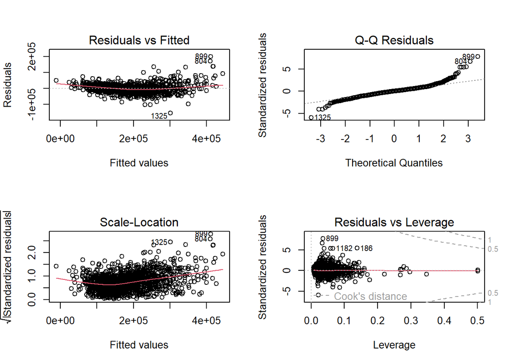

```r
par(mfrow=c(2,2))
plot(mod1)
```

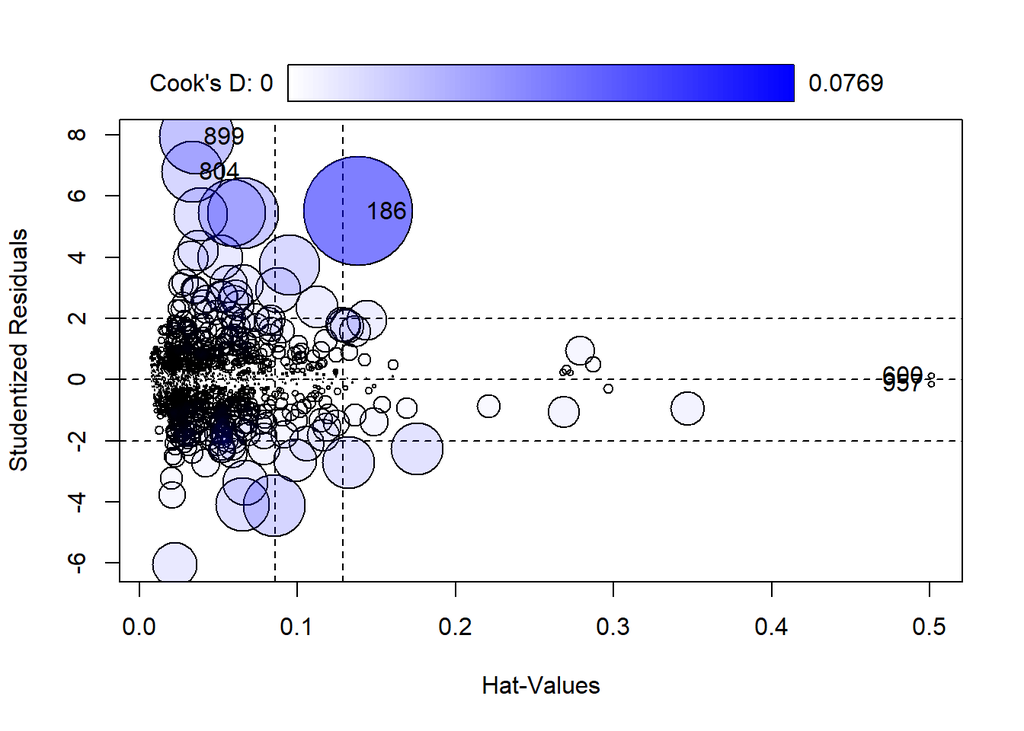

```
##        StudRes        Hat        CookD
## 186  5.5005256 0.13854284 0.0768533616
## 600  0.1306535 0.50084749 0.0002764595
## 804  6.7902751 0.03305133 0.0246155653
## 899  7.9368988 0.03593345 0.0362435628
## 957 -0.1306535 0.50084749 0.0002764595
```

```r
## We can see that the extreme values are not being predicted very well so we will apply a log transformation in order to improve the performance.
par(mfrow=c(1,1))
influencePlot(mod1)
```

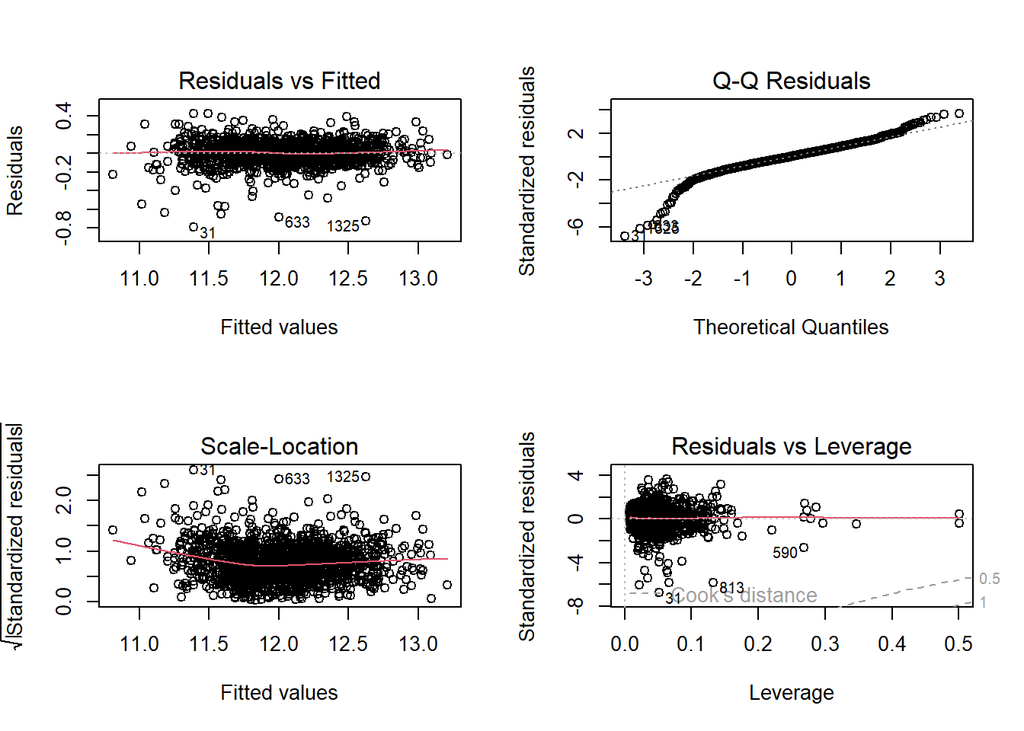

```r
mod2 <- lm(log(SalePrice) ~ log_LotFrontage + log_LotArea + X1stFlrSF + X2ndFlrSF + YearBuilt + GarageCars + BedroomAbvGr + KitchenAbvGr + TotRmsAbvGrd + Neighborhood + MSSubClass + log_TotalBsmtSF + OverallCond + OverallQual + FireplaceQu + ScreenPorch + SaleCondition, data=df_model)

par(mfrow=c(2,2))
plot(mod2)
```

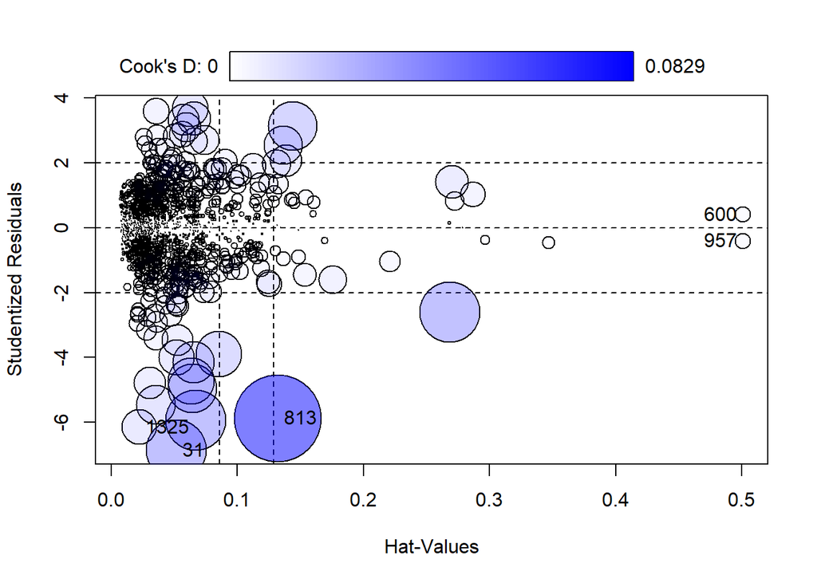

```
##         StudRes        Hat       CookD
## 31   -6.8688931 0.05168713 0.040135343
## 600   0.4105935 0.50084749 0.002730023
## 813  -5.8834616 0.13204437 0.082918592
## 957  -0.4105935 0.50084749 0.002730023
## 1325 -6.1610707 0.02229819 0.013599220
```

```r
par(mfrow=c(1,1))
influencePlot(mod2)
```

```r
## Delete non significant
summary(mod2)
```

```
##
## Call:
## lm(formula = log(SalePrice) ~ log_LotFrontage + log_LotArea +
##     X1stFlrSF + X2ndFlrSF + YearBuilt + GarageCars + BedroomAbvGr +
##     KitchenAbvGr + TotRmsAbvGrd + Neighborhood + MSSubClass +
##     log_TotalBsmtSF + OverallCond + OverallQual + FireplaceQu +
##     ScreenPorch + SaleCondition, data = df_model)
##
## Residuals:
##      Min       1Q   Median       3Q      Max
## -0.79188 -0.06090  0.00288  0.07054  0.42506
##
## Coefficients:
##                          Estimate Std. Error t value Pr(>|t|)
## (Intercept)             2.933e+00  6.560e-01   4.471 8.43e-06 ***
## log_LotFrontage        -1.126e-02  1.561e-02  -0.722 0.470695
## log_LotArea             8.961e-02  1.153e-02   7.774 1.48e-14 ***
## X1stFlrSF               3.717e-04  1.889e-05  19.683  < 2e-16 ***
## X2ndFlrSF               2.525e-04  2.233e-05  11.311  < 2e-16 ***
## YearBuilt               3.559e-03  3.176e-04  11.207  < 2e-16 ***
## GarageCars              4.786e-02  6.238e-03   7.672 3.17e-14 ***
## BedroomAbvGr           -2.287e-02  6.356e-03  -3.598 0.000331 ***
## KitchenAbvGr           -7.771e-02  2.611e-02  -2.976 0.002969 **
## TotRmsAbvGrd            6.402e-03  4.573e-03   1.400 0.161822
## NeighborhoodBlueste     4.600e-02  9.398e-02   0.489 0.624593
## NeighborhoodBrDale     -1.074e-02  5.061e-02  -0.212 0.831932
## NeighborhoodBrkSide     3.779e-02  4.136e-02   0.914 0.361027
## NeighborhoodClearCr     8.492e-02  4.347e-02   1.953 0.050970 .
## NeighborhoodCollgCr     2.574e-02  3.570e-02   0.721 0.471134
## NeighborhoodCrawfor     1.323e-01  4.031e-02   3.282 0.001055 **
## NeighborhoodEdwards    -2.353e-02  3.852e-02  -0.611 0.541474
## NeighborhoodGilbert    -6.388e-03  3.764e-02  -0.170 0.865280
## NeighborhoodIDOTRR     -7.341e-02  4.335e-02  -1.693 0.090603 .
## NeighborhoodMeadowV    -6.227e-02  5.096e-02  -1.222 0.221926
## NeighborhoodMitchel    -1.129e-02  3.929e-02  -0.287 0.773881
## NeighborhoodNAmes       2.405e-03  3.701e-02   0.065 0.948191
## NeighborhoodNoRidge     8.690e-02  4.054e-02   2.144 0.032245 *
## NeighborhoodNPkVill     3.793e-02  5.269e-02   0.720 0.471728
## NeighborhoodNridgHt     1.219e-01  3.545e-02   3.437 0.000605 ***
## NeighborhoodNWAmes     -4.584e-02  3.793e-02  -1.209 0.227022
```

[output cut: 27 more lines]

```
## FireplaceQu4           -6.036e-02  3.934e-02  -1.534 0.125219
## FireplaceQu5           -4.202e-02  2.836e-02  -1.482 0.138585
## FireplaceQuNoFirePlace -6.588e-02  2.858e-02  -2.305 0.021300 *
## ScreenPorch             2.326e-04  6.091e-05   3.818 0.000140 ***
## SaleConditionAbnorml   -7.659e-02  1.305e-02  -5.869 5.50e-09 ***
## SaleConditionAdjLand    4.039e-02  6.361e-02   0.635 0.525634
## SaleConditionAlloca    -4.163e-02  3.732e-02  -1.115 0.264894
## SaleConditionFamily    -5.913e-02  2.777e-02  -2.129 0.033439 *
## SaleConditionPartial    3.617e-02  1.358e-02   2.663 0.007825 **
## ---
## Signif. codes:  0 '***' 0.001 '**' 0.01 '*' 0.05 '.' 0.1 ' ' 1
##
## Residual standard error: 0.1203 on 1381 degrees of freedom
## Multiple R-squared:   0.91,  Adjusted R-squared:  0.906
## F-statistic: 228.9 on 61 and 1381 DF,  p-value: < 2.2e-16
```

```r
mod3 <- lm(log(SalePrice) ~ log_LotArea + X1stFlrSF + X2ndFlrSF + YearBuilt + GarageCars + BedroomAbvGr + KitchenAbvGr + Neighborhood + MSSubClass + log_TotalBsmtSF + OverallCond + OverallQual + FireplaceQu + ScreenPorch + SaleCondition, data=df_model)
summary(mod3)
```

```
##
## Call:
## lm(formula = log(SalePrice) ~ log_LotArea + X1stFlrSF + X2ndFlrSF +
##     YearBuilt + GarageCars + BedroomAbvGr + KitchenAbvGr + Neighborhood +
##     MSSubClass + log_TotalBsmtSF + OverallCond + OverallQual +
##     FireplaceQu + ScreenPorch + SaleCondition, data = df_model)
##
## Residuals:
##      Min       1Q   Median       3Q      Max
## -0.79360 -0.06201  0.00316  0.06767  0.43089
##
## Coefficients:
##                          Estimate Std. Error t value Pr(>|t|)
## (Intercept)             2.901e+00  6.526e-01   4.445 9.50e-06 ***
## log_LotArea             8.727e-02  1.119e-02   7.801 1.20e-14 ***
## X1stFlrSF               3.833e-04  1.648e-05  23.257  < 2e-16 ***
## X2ndFlrSF               2.649e-04  2.056e-05  12.885  < 2e-16 ***
## YearBuilt               3.566e-03  3.173e-04  11.240  < 2e-16 ***
## GarageCars              4.785e-02  6.224e-03   7.688 2.82e-14 ***
## BedroomAbvGr           -1.934e-02  5.724e-03  -3.378 0.000750 ***
## KitchenAbvGr           -6.923e-02  2.545e-02  -2.720 0.006603 **
## NeighborhoodBlueste     4.286e-02  9.384e-02   0.457 0.647919
## NeighborhoodBrDale     -8.190e-03  5.034e-02  -0.163 0.870777
## NeighborhoodBrkSide     3.070e-02  4.075e-02   0.753 0.451359
## NeighborhoodClearCr     8.011e-02  4.293e-02   1.866 0.062234 .
## NeighborhoodCollgCr     1.973e-02  3.521e-02   0.561 0.575229
## NeighborhoodCrawfor     1.248e-01  3.990e-02   3.129 0.001792 **
## NeighborhoodEdwards    -2.929e-02  3.813e-02  -0.768 0.442620
## NeighborhoodGilbert    -1.149e-02  3.730e-02  -0.308 0.758010
## NeighborhoodIDOTRR     -7.801e-02  4.307e-02  -1.811 0.070297 .
## NeighborhoodMeadowV    -6.619e-02  5.076e-02  -1.304 0.192456
## NeighborhoodMitchel    -1.815e-02  3.877e-02  -0.468 0.639769
## NeighborhoodNAmes      -4.355e-03  3.660e-02  -0.119 0.905296
## NeighborhoodNoRidge     7.685e-02  3.984e-02   1.929 0.053962 .
## NeighborhoodNPkVill     3.725e-02  5.260e-02   0.708 0.478899
## NeighborhoodNridgHt     1.178e-01  3.533e-02   3.334 0.000880 ***
## NeighborhoodNWAmes     -5.203e-02  3.758e-02  -1.385 0.166339
## NeighborhoodOldTown    -4.120e-02  3.959e-02  -1.040 0.298294
## NeighborhoodSawyer     -2.272e-02  3.847e-02  -0.591 0.554913
## NeighborhoodSawyerW    -4.775e-03  3.743e-02  -0.128 0.898523
```

[output cut: 24 more lines]

```
## FireplaceQu4           -5.929e-02  3.933e-02  -1.507 0.131939
## FireplaceQu5           -4.151e-02  2.835e-02  -1.464 0.143408
## FireplaceQuNoFirePlace -6.488e-02  2.857e-02  -2.271 0.023292 *
## ScreenPorch             2.325e-04  6.090e-05   3.817 0.000141 ***
## SaleConditionAbnorml   -7.668e-02  1.305e-02  -5.874 5.32e-09 ***
## SaleConditionAdjLand    4.427e-02  6.356e-02   0.697 0.486196
## SaleConditionAlloca    -4.097e-02  3.733e-02  -1.098 0.272587
## SaleConditionFamily    -5.827e-02  2.777e-02  -2.098 0.036057 *
## SaleConditionPartial    3.681e-02  1.356e-02   2.716 0.006699 **
## ---
## Signif. codes:  0 '***' 0.001 '**' 0.01 '*' 0.05 '.' 0.1 ' ' 1
##
## Residual standard error: 0.1204 on 1383 degrees of freedom
## Multiple R-squared:  0.9098, Adjusted R-squared:  0.906
## F-statistic: 236.5 on 59 and 1383 DF,  p-value: < 2.2e-16
```

## Interpretation of the model

```r
smod <- summary(mod3)
vif(mod2) %>% round(2) %>% t
```

```
##                 log_LotFrontage log_LotArea X1stFlrSF X2ndFlrSF YearBuilt
## GVIF                       2.84        3.47      4.71      9.10      9.14
## Df                         1.00        1.00      1.00      1.00      1.00
## GVIF^(1/(2*Df))            1.68        1.86      2.17      3.02      3.02
##                 GarageCars BedroomAbvGr KitchenAbvGr TotRmsAbvGrd Neighborhood
## GVIF                  2.15         2.66         3.25         5.36       248.59
## Df                    1.00         1.00         1.00         1.00        24.00
## GVIF^(1/(2*Df))       1.47         1.63         1.80         2.31         1.12
##                 MSSubClass log_TotalBsmtSF OverallCond OverallQual FireplaceQu
## GVIF               1160.16            1.34        1.41        3.79        2.84
## Df                   14.00            1.00        1.00        1.00        5.00
## GVIF^(1/(2*Df))       1.29            1.16        1.19        1.95        1.11
##                 ScreenPorch SaleCondition
## GVIF                   1.08          2.00
## Df                     1.00          5.00
## GVIF^(1/(2*Df))        1.04          1.07
```

```r
mod2$coefficients %>% round(5)
```

```
##            (Intercept)        log_LotFrontage            log_LotArea
##                2.93278               -0.01126                0.08961
##              X1stFlrSF              X2ndFlrSF              YearBuilt
##                0.00037                0.00025                0.00356
##             GarageCars           BedroomAbvGr           KitchenAbvGr
##                0.04786               -0.02287               -0.07771
##           TotRmsAbvGrd    NeighborhoodBlueste     NeighborhoodBrDale
##                0.00640                0.04600               -0.01074
##    NeighborhoodBrkSide    NeighborhoodClearCr    NeighborhoodCollgCr
##                0.03779                0.08492                0.02574
##    NeighborhoodCrawfor    NeighborhoodEdwards    NeighborhoodGilbert
##                0.13233               -0.02353               -0.00639
##     NeighborhoodIDOTRR    NeighborhoodMeadowV    NeighborhoodMitchel
##               -0.07341               -0.06227               -0.01129
##      NeighborhoodNAmes    NeighborhoodNoRidge    NeighborhoodNPkVill
##                0.00241                0.08690                0.03793
##    NeighborhoodNridgHt     NeighborhoodNWAmes    NeighborhoodOldTown
##                0.12187               -0.04584               -0.03470
##     NeighborhoodSawyer    NeighborhoodSawyerW    NeighborhoodSomerst
##               -0.01655                0.00206                0.09224
##    NeighborhoodStoneBr      NeighborhoodSWISU     NeighborhoodTimber
##                0.16631                0.05700                0.04039
##    NeighborhoodVeenker           MSSubClass30           MSSubClass40
##                0.08099               -0.06311               -0.03168
##           MSSubClass45           MSSubClass50           MSSubClass60
##               -0.05576               -0.00902                0.00864
##           MSSubClass70           MSSubClass75           MSSubClass80
##                0.02100                0.03640                0.00662
##           MSSubClass85           MSSubClass90          MSSubClass120
##                0.03177                0.00081               -0.01252
##          MSSubClass160          MSSubClass180          MSSubClass190
##               -0.05810               -0.01436                0.02690
##        log_TotalBsmtSF            OverallCond            OverallQual
##                0.02569                0.05448                0.06003
##           FireplaceQu2           FireplaceQu3           FireplaceQu4
##               -0.02214               -0.03249               -0.06036
##           FireplaceQu5 FireplaceQuNoFirePlace            ScreenPorch
##               -0.04202               -0.06588                0.00023
##   SaleConditionAbnorml   SaleConditionAdjLand    SaleConditionAlloca
##               -0.07659                0.04039               -0.04163
##    SaleConditionFamily   SaleConditionPartial
##               -0.05913                0.03617
```

```r
r2 <- smod$r.squared %>% round(2)
adj.r2 <- smod$adj.r.squared %>% round(2)
smod
```

```
##
## Call:
## lm(formula = log(SalePrice) ~ log_LotArea + X1stFlrSF + X2ndFlrSF +
##     YearBuilt + GarageCars + BedroomAbvGr + KitchenAbvGr + Neighborhood +
##     MSSubClass + log_TotalBsmtSF + OverallCond + OverallQual +
##     FireplaceQu + ScreenPorch + SaleCondition, data = df_model)
##
## Residuals:
##      Min       1Q   Median       3Q      Max
## -0.79360 -0.06201  0.00316  0.06767  0.43089
##
## Coefficients:
##                          Estimate Std. Error t value Pr(>|t|)
## (Intercept)             2.901e+00  6.526e-01   4.445 9.50e-06 ***
## log_LotArea             8.727e-02  1.119e-02   7.801 1.20e-14 ***
## X1stFlrSF               3.833e-04  1.648e-05  23.257  < 2e-16 ***
## X2ndFlrSF               2.649e-04  2.056e-05  12.885  < 2e-16 ***
## YearBuilt               3.566e-03  3.173e-04  11.240  < 2e-16 ***
## GarageCars              4.785e-02  6.224e-03   7.688 2.82e-14 ***
## BedroomAbvGr           -1.934e-02  5.724e-03  -3.378 0.000750 ***
## KitchenAbvGr           -6.923e-02  2.545e-02  -2.720 0.006603 **
## NeighborhoodBlueste     4.286e-02  9.384e-02   0.457 0.647919
## NeighborhoodBrDale     -8.190e-03  5.034e-02  -0.163 0.870777
## NeighborhoodBrkSide     3.070e-02  4.075e-02   0.753 0.451359
## NeighborhoodClearCr     8.011e-02  4.293e-02   1.866 0.062234 .
## NeighborhoodCollgCr     1.973e-02  3.521e-02   0.561 0.575229
## NeighborhoodCrawfor     1.248e-01  3.990e-02   3.129 0.001792 **
## NeighborhoodEdwards    -2.929e-02  3.813e-02  -0.768 0.442620
## NeighborhoodGilbert    -1.149e-02  3.730e-02  -0.308 0.758010
## NeighborhoodIDOTRR     -7.801e-02  4.307e-02  -1.811 0.070297 .
## NeighborhoodMeadowV    -6.619e-02  5.076e-02  -1.304 0.192456
## NeighborhoodMitchel    -1.815e-02  3.877e-02  -0.468 0.639769
## NeighborhoodNAmes      -4.355e-03  3.660e-02  -0.119 0.905296
## NeighborhoodNoRidge     7.685e-02  3.984e-02   1.929 0.053962 .
## NeighborhoodNPkVill     3.725e-02  5.260e-02   0.708 0.478899
## NeighborhoodNridgHt     1.178e-01  3.533e-02   3.334 0.000880 ***
## NeighborhoodNWAmes     -5.203e-02  3.758e-02  -1.385 0.166339
## NeighborhoodOldTown    -4.120e-02  3.959e-02  -1.040 0.298294
## NeighborhoodSawyer     -2.272e-02  3.847e-02  -0.591 0.554913
## NeighborhoodSawyerW    -4.775e-03  3.743e-02  -0.128 0.898523
```

[output cut: 24 more lines]

```
## FireplaceQu4           -5.929e-02  3.933e-02  -1.507 0.131939
## FireplaceQu5           -4.151e-02  2.835e-02  -1.464 0.143408
## FireplaceQuNoFirePlace -6.488e-02  2.857e-02  -2.271 0.023292 *
## ScreenPorch             2.325e-04  6.090e-05   3.817 0.000141 ***
## SaleConditionAbnorml   -7.668e-02  1.305e-02  -5.874 5.32e-09 ***
## SaleConditionAdjLand    4.427e-02  6.356e-02   0.697 0.486196
## SaleConditionAlloca    -4.097e-02  3.733e-02  -1.098 0.272587
## SaleConditionFamily    -5.827e-02  2.777e-02  -2.098 0.036057 *
## SaleConditionPartial    3.681e-02  1.356e-02   2.716 0.006699 **
## ---
## Signif. codes:  0 '***' 0.001 '**' 0.01 '*' 0.05 '.' 0.1 ' ' 1
##
## Residual standard error: 0.1204 on 1383 degrees of freedom
## Multiple R-squared:  0.9098, Adjusted R-squared:  0.906
## F-statistic: 236.5 on 59 and 1383 DF,  p-value: < 2.2e-16
```

As we can see in the summary of model we selected all variables that are significant in order to predict the Sale Price. We have an overall R-squared of 0.91 and an Adjusted R-squared of 0.91 and the p-value of the model is << 0.05, so we can say it is significant and the variables can predict in some way the response variable.

As for MSSubClass the reference level is the level 20 - “1-STORY 1946 & NEWER ALL STYLES”. We have little significant factors with this reference level, we will expect lowe prices for the level 30 - 1-STORY 1945 & OLDER and level 160 - “2-STORY PUD - 1946 & NEWER”.

Moreover we have negative correlation in the No Fireplaces comparing it with the reference level 1 fireplace. The rest of the levels are not significant compared with the level 1.

Overall Condition and Overall Quality of the house is positively correlated with Price as well as the number of Squared Feet of the basement.

The Screen Porch area is significant and is positively correlated with Price.

The Sale condition reduces the price with the reference level “Normal” when comparing with Abnormal and Family, in contrast increases the price when the Sale Condition is partial.

```r
smod <- summary(mod3)
vif(mod2) %>% round(2) %>% t
```

```
##                 log_LotFrontage log_LotArea X1stFlrSF X2ndFlrSF YearBuilt
## GVIF                       2.84        3.47      4.71      9.10      9.14
## Df                         1.00        1.00      1.00      1.00      1.00
## GVIF^(1/(2*Df))            1.68        1.86      2.17      3.02      3.02
##                 GarageCars BedroomAbvGr KitchenAbvGr TotRmsAbvGrd Neighborhood
## GVIF                  2.15         2.66         3.25         5.36       248.59
## Df                    1.00         1.00         1.00         1.00        24.00
## GVIF^(1/(2*Df))       1.47         1.63         1.80         2.31         1.12
##                 MSSubClass log_TotalBsmtSF OverallCond OverallQual FireplaceQu
## GVIF               1160.16            1.34        1.41        3.79        2.84
## Df                   14.00            1.00        1.00        1.00        5.00
## GVIF^(1/(2*Df))       1.29            1.16        1.19        1.95        1.11
##                 ScreenPorch SaleCondition
## GVIF                   1.08          2.00
## Df                     1.00          5.00
## GVIF^(1/(2*Df))        1.04          1.07
```

```r
mod2$coefficients %>% round(5)
```

```
##            (Intercept)        log_LotFrontage            log_LotArea
##                2.93278               -0.01126                0.08961
##              X1stFlrSF              X2ndFlrSF              YearBuilt
##                0.00037                0.00025                0.00356
##             GarageCars           BedroomAbvGr           KitchenAbvGr
##                0.04786               -0.02287               -0.07771
##           TotRmsAbvGrd    NeighborhoodBlueste     NeighborhoodBrDale
##                0.00640                0.04600               -0.01074
##    NeighborhoodBrkSide    NeighborhoodClearCr    NeighborhoodCollgCr
##                0.03779                0.08492                0.02574
##    NeighborhoodCrawfor    NeighborhoodEdwards    NeighborhoodGilbert
##                0.13233               -0.02353               -0.00639
##     NeighborhoodIDOTRR    NeighborhoodMeadowV    NeighborhoodMitchel
##               -0.07341               -0.06227               -0.01129
##      NeighborhoodNAmes    NeighborhoodNoRidge    NeighborhoodNPkVill
##                0.00241                0.08690                0.03793
##    NeighborhoodNridgHt     NeighborhoodNWAmes    NeighborhoodOldTown
##                0.12187               -0.04584               -0.03470
##     NeighborhoodSawyer    NeighborhoodSawyerW    NeighborhoodSomerst
##               -0.01655                0.00206                0.09224
##    NeighborhoodStoneBr      NeighborhoodSWISU     NeighborhoodTimber
##                0.16631                0.05700                0.04039
##    NeighborhoodVeenker           MSSubClass30           MSSubClass40
##                0.08099               -0.06311               -0.03168
##           MSSubClass45           MSSubClass50           MSSubClass60
##               -0.05576               -0.00902                0.00864
##           MSSubClass70           MSSubClass75           MSSubClass80
##                0.02100                0.03640                0.00662
##           MSSubClass85           MSSubClass90          MSSubClass120
##                0.03177                0.00081               -0.01252
##          MSSubClass160          MSSubClass180          MSSubClass190
##               -0.05810               -0.01436                0.02690
##        log_TotalBsmtSF            OverallCond            OverallQual
##                0.02569                0.05448                0.06003
##           FireplaceQu2           FireplaceQu3           FireplaceQu4
##               -0.02214               -0.03249               -0.06036
##           FireplaceQu5 FireplaceQuNoFirePlace            ScreenPorch
##               -0.04202               -0.06588                0.00023
##   SaleConditionAbnorml   SaleConditionAdjLand    SaleConditionAlloca
##               -0.07659                0.04039               -0.04163
##    SaleConditionFamily   SaleConditionPartial
##               -0.05913                0.03617
```

```r
r2 <- smod$r.squared %>% round(2)
adj.r2 <- smod$adj.r.squared %>% round(2)
smod
```

```
##
## Call:
## lm(formula = log(SalePrice) ~ log_LotArea + X1stFlrSF + X2ndFlrSF +
##     YearBuilt + GarageCars + BedroomAbvGr + KitchenAbvGr + Neighborhood +
##     MSSubClass + log_TotalBsmtSF + OverallCond + OverallQual +
##     FireplaceQu + ScreenPorch + SaleCondition, data = df_model)
##
## Residuals:
##      Min       1Q   Median       3Q      Max
## -0.79360 -0.06201  0.00316  0.06767  0.43089
##
## Coefficients:
##                          Estimate Std. Error t value Pr(>|t|)
## (Intercept)             2.901e+00  6.526e-01   4.445 9.50e-06 ***
## log_LotArea             8.727e-02  1.119e-02   7.801 1.20e-14 ***
## X1stFlrSF               3.833e-04  1.648e-05  23.257  < 2e-16 ***
## X2ndFlrSF               2.649e-04  2.056e-05  12.885  < 2e-16 ***
## YearBuilt               3.566e-03  3.173e-04  11.240  < 2e-16 ***
## GarageCars              4.785e-02  6.224e-03   7.688 2.82e-14 ***
## BedroomAbvGr           -1.934e-02  5.724e-03  -3.378 0.000750 ***
## KitchenAbvGr           -6.923e-02  2.545e-02  -2.720 0.006603 **
## NeighborhoodBlueste     4.286e-02  9.384e-02   0.457 0.647919
## NeighborhoodBrDale     -8.190e-03  5.034e-02  -0.163 0.870777
## NeighborhoodBrkSide     3.070e-02  4.075e-02   0.753 0.451359
## NeighborhoodClearCr     8.011e-02  4.293e-02   1.866 0.062234 .
## NeighborhoodCollgCr     1.973e-02  3.521e-02   0.561 0.575229
## NeighborhoodCrawfor     1.248e-01  3.990e-02   3.129 0.001792 **
## NeighborhoodEdwards    -2.929e-02  3.813e-02  -0.768 0.442620
## NeighborhoodGilbert    -1.149e-02  3.730e-02  -0.308 0.758010
## NeighborhoodIDOTRR     -7.801e-02  4.307e-02  -1.811 0.070297 .
## NeighborhoodMeadowV    -6.619e-02  5.076e-02  -1.304 0.192456
## NeighborhoodMitchel    -1.815e-02  3.877e-02  -0.468 0.639769
## NeighborhoodNAmes      -4.355e-03  3.660e-02  -0.119 0.905296
## NeighborhoodNoRidge     7.685e-02  3.984e-02   1.929 0.053962 .
## NeighborhoodNPkVill     3.725e-02  5.260e-02   0.708 0.478899
## NeighborhoodNridgHt     1.178e-01  3.533e-02   3.334 0.000880 ***
## NeighborhoodNWAmes     -5.203e-02  3.758e-02  -1.385 0.166339
## NeighborhoodOldTown    -4.120e-02  3.959e-02  -1.040 0.298294
## NeighborhoodSawyer     -2.272e-02  3.847e-02  -0.591 0.554913
## NeighborhoodSawyerW    -4.775e-03  3.743e-02  -0.128 0.898523
```

[output cut: 24 more lines]

```
## FireplaceQu4           -5.929e-02  3.933e-02  -1.507 0.131939
## FireplaceQu5           -4.151e-02  2.835e-02  -1.464 0.143408
## FireplaceQuNoFirePlace -6.488e-02  2.857e-02  -2.271 0.023292 *
## ScreenPorch             2.325e-04  6.090e-05   3.817 0.000141 ***
## SaleConditionAbnorml   -7.668e-02  1.305e-02  -5.874 5.32e-09 ***
## SaleConditionAdjLand    4.427e-02  6.356e-02   0.697 0.486196
## SaleConditionAlloca    -4.097e-02  3.733e-02  -1.098 0.272587
## SaleConditionFamily    -5.827e-02  2.777e-02  -2.098 0.036057 *
## SaleConditionPartial    3.681e-02  1.356e-02   2.716 0.006699 **
## ---
## Signif. codes:  0 '***' 0.001 '**' 0.01 '*' 0.05 '.' 0.1 ' ' 1
##
## Residual standard error: 0.1204 on 1383 degrees of freedom
## Multiple R-squared:  0.9098, Adjusted R-squared:  0.906
## F-statistic: 236.5 on 59 and 1383 DF,  p-value: < 2.2e-16
```

## Test Preprocessing

```r
#df_test <- read.csv("C:/Users/inigo/Documents/UPC/SIM/SIM-project/data/test.csv")
df_test <- read.csv("C:/MDS/SIM/Project/data/test.csv")

numeric_columns <- c("LotFrontage", "LotArea", "YearBuilt", "YearRemodAdd", "MasVnrArea", "BsmtFinSF1", "BsmtFinSF2", "BsmtUnfSF", "TotalBsmtSF", "X1stFlrSF", "X2ndFlrSF", "LowQualFinSF", "GrLivArea", "BsmtFullBath", "BsmtHalfBath", "FullBath", "HalfBath", "BedroomAbvGr", "KitchenAbvGr", "TotRmsAbvGrd", "Fireplaces", "GarageYrBlt", "GarageCars", "GarageArea", "WoodDeckSF", "OpenPorchSF", "EnclosedPorch", "X3SsnPorch", "ScreenPorch", "PoolArea", "MiscVal", "MoSold", "YrSold", "OverallCond","OverallQual")

cat_keep <- c("FireplaceQu","KitchenQual","BsmtFinType1","BsmtExposure","BsmtQual","Foundation","Neighborhood","LotShape","MSSubClass","Exterior1st","Exterior2nd", "SaleCondition")

df1_test <- df_test %>% select(all_of(numeric_columns), all_of(cat_keep))

df1_test[cat_keep] <- lapply(df1_test[cat_keep], as.factor) ## Create Factors
df1_test[numeric_columns] <- lapply(df1_test[numeric_columns], as.numeric)

num_outliers <- c("BsmtFinSF1", "BsmtFinSF2", "BsmtHalfBath", "BsmtUnfSF", "EnclosedPorch", "GarageArea", "GrLivArea","LotArea", "LotFrontage", "LowQualFinSF", "MasVnrArea","MiscVal","OpenPorchSF","PoolArea","ScreenPorch","TotalBsmtSF", "WoodDeckSF","X1stFlrSF","X3SsnPorch")


## Impute missing data by creating extra modality

df1_test$FireplaceQu <- ifelse(df1_test$FireplaceQu %>% is.na, "NoFirePlace", df1_test$FireplaceQu)
df1_test$BsmtExposure <- ifelse(df1_test$BsmtExposure %>% is.na, "NoBasement", df1_test$BsmtExposure)
df1_test$BsmtFinType1 <- ifelse(df1_test$BsmtFinType1 %>% is.na, "NoBasement", df1_test$BsmtFinType1)
df1_test$BsmtQual <- ifelse(df1_test$BsmtQual %>% is.na, "NoBasement", df1_test$BsmtQual)

df1_test$garage <- ifelse(df1_test$GarageYrBlt %>% is.na, "NO", "YES")
## Impute with synthetic values

df2_test <- mice(df1_test, method = "cart", m = 1)
df3_test <- complete(df2_test)

df3_test$log_LotArea <- log(df3_test$LotArea + 1)
df3_test$log_LotFrontage <- log(df3_test$LotFrontage + 1)
df3_test$log_TotalBsmtSF <- log(df3_test$TotalBsmtSF + 1)

df3_test$YearRemodAdd <- df3_test$YearRemodAdd - df3_test$YearBuilt

df3_test$bsmt <- ifelse(df3_test$log_TotalBsmtSF == 0, "NO","YES")

df3_test$cat_BsmntFinSF2 <- ifelse(df3_test$BsmtFinSF2 > 0, "Yes","Zero")
df3_test$cat_EnclosedPorch <- ifelse(df3_test$EnclosedPorch > 0, "Yes","Zero")
df3_test$cat_LowQualFinSF <- ifelse(df3_test$LowQualFinSF > 0, "Yes","Zero")
df3_test$cat_MiscVal <- ifelse(df3_test$MiscVal > 0, "Yes","Zero")
df3_test$cat_PoolArea <- ifelse(df3_test$PoolArea > 0, "Yes","No")
df3_test$cat_ScreenPorch <- ifelse(df3_test$ScreenPorch > 0, "Yes","No")
df3_test$cat_X3SsnPorch <- ifelse(df3_test$X3SsnPorch > 0, "Yes","No")
df3_test$remod <- ifelse(df3_test$YearRemodAdd == 0, "No", "Yes")
```

# Predictions of the test data

```r
df_model_test <- df3_test %>% select(
  c(
    "log_LotFrontage",
    "log_LotArea",
    "YearBuilt",
    "YearRemodAdd",
    "FullBath",
    "garage",
    "GarageArea",
    "bsmt",
    "log_TotalBsmtSF",
    "cat_PoolArea",
    "YrSold",
    "MoSold",
    "remod",
    "GarageCars",
    "GarageYrBlt",
    "BedroomAbvGr",
    "KitchenAbvGr",
    "TotRmsAbvGrd",
    "Neighborhood",
    "GrLivArea",
    "MSSubClass",
    "X1stFlrSF",
    "X2ndFlrSF",
    "OverallCond",
    "OverallQual",
    "FireplaceQu",
    "cat_MiscVal",
    "OpenPorchSF",
    "cat_EnclosedPorch",
    "cat_LowQualFinSF",
    "cat_X3SsnPorch",
    "ScreenPorch",
    "Foundation",
    "Exterior1st",
    "Exterior2nd",
    "SaleCondition"
    )
)
attach(df_model_test)

df_model_test <- df_model_test[df_model_test$MSSubClass %in% (df_model$MSSubClass %>% unique), ]
df_model_test <- df_model_test[df_model_test$Neighborhood %in% (df_model$Neighborhood %>% unique), ]


predictions <- predict(mod2, newdata = df_model_test, type = "response")

final_predictions <- exp(predictions)


## Assessing forecasting capabilities
smp <- sample(x=nrow(df_model),nrow(df_model)*0.75, replace=FALSE)

train <- df_model[smp,]
test <- df_model[-smp,]

test <- test[test$MSSubClass %in% (train$MSSubClass %>% unique), ]
test <- test[test$Neighborhood %in% (train$Neighborhood %>% unique), ]


mod2 <- lm(log(SalePrice) ~ log_LotFrontage + log_LotArea + X1stFlrSF + X2ndFlrSF + YearBuilt + GarageCars + BedroomAbvGr + KitchenAbvGr + TotRmsAbvGrd + Neighborhood + MSSubClass + log_TotalBsmtSF + OverallCond + OverallQual + FireplaceQu + ScreenPorch, data=train)

predictions <- predict(mod2, test)
predictions <- exp(predictions)

deviation <- (test$SalePrice - predictions)/test$SalePrice
deviation_abs <- (abs(test$SalePrice - predictions)/test$SalePrice)
mean(deviation_abs)
```

```
## [1] 0.09496059
```

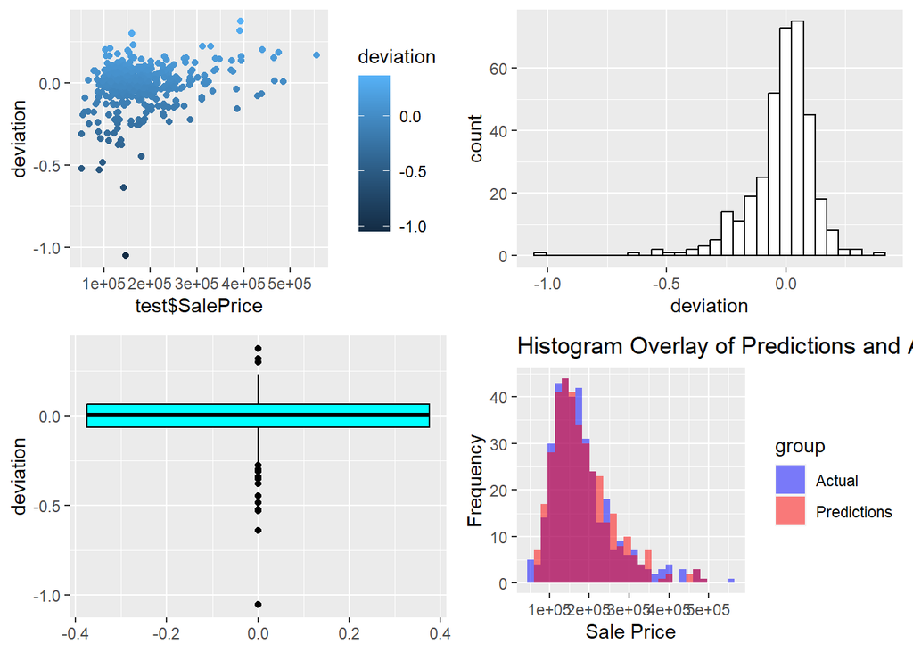

```r
## The median deviation is 8.8%

g1 <- ggplot() + geom_jitter(mapping = aes(x=test$SalePrice, y=deviation, colour=deviation))
g2 <- ggplot() + geom_histogram(mapping = aes(x=deviation), fill="white", colour="black")
g3 <- ggplot() + geom_boxplot(mapping = aes(y=deviation), fill="cyan", colour="black")



# Create a data frame for the overlay
overlay_data <- data.frame(
  value = c(predictions, test$SalePrice),
  group = rep(c("Predictions", "Actual"),
              each = c(length(predictions), length(test$SalePrice))
              )
)
# Create the histogram with ggplot2
g4 <- ggplot(overlay_data, aes(x = value, fill = group)) +
  geom_histogram(position = "identity", alpha = 0.5, bins = 30) +
  labs(title = "Histogram Overlay of Predictions and Actual SalePrice",
       x = "Sale Price",
       y = "Frequency") +
  scale_fill_manual(values = c("blue", "red"))
## The distributions look very similar


grid.arrange(g1,g2,g3,g4)
```